# This slide intentionally left blank

### Contributing to the napari community:

#### widgets, plugins, napari core, documentation—oh my!

**Peter Sobolewski (he/him)**

> Systems Analyst  
> Imaging Applications  
> Research IT  
> The Jackson Laboratory

> Member, napari core developer team

## What is napari?

a Python library for n-dimensional image visualisation, annotation, and analysis.

[figure not shown]

## What can napari be used for?

- view & explore 2D, 3D, and higher-dimensional arrays
- overlay derived data such as points, polygons, labels, and more
- seamlessly weave exploration, computation, and annotation together in imaging data analysis
- leverage scientific Python ecosystem

## napari is an open-source, community developed project—anyone can contribute!

## What is the napari community?

- napari users: local and global
- napari plugin developers
- napari core developers
- broader scientific Python community

## Ask and answer questions!

- image.sc forum: https://forum.image.sc/tag/napari
- napari Zulip chat: https://napari.zulipchat.com
- napari community meetings: https://napari.org/stable/community/meeting_schedule.html

No accounts are needed to lurk…

## Report bugs—or test existing ones

- GitHub Issues: https://github.com/napari/napari/issues
- Reporting bugs/problems/inconstencies/confusion is **extremely valuable!**
- When in doubt, report—we prefer duplicates than crickets!

This does require an account (free), **but you can use that account to login at image.sc and zulipchat.com!**

## Discuss features and use-cases

- napari roadmap: https://github.com/orgs/napari/projects/24/views/1
- GitHub Issues: https://github.com/napari/napari/issues

Please check existing issues and/or join a Community meeting!

# Headless napari is just Python!

### – Juan Nunez-Iglesias (**@jni**)

## Share Python scripts & notebooks!

**expand for full code**

```python
from skimage import data
from scipy import ndimage as ndi

import napari

blobs = data.binary_blobs(length=128, volume_fraction=0.1, n_dim=3)
labeled = ndi.label(blobs)[0]
viewer, image_layer = napari.imshow(blobs, name='blobs')
viewer.add_labels(labeled, name='blob ID')
viewer.dims.ndisplay = 3
viewer.camera.zoom = 3
viewer.camera.angles = (3, 38, 53)

if __name__ == '__main__':
    napari.run()
```

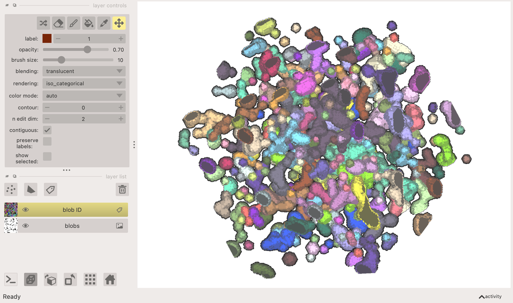

## Python scripts can handle keyboard and mouse events!

- Customize napari functionality:
  - keyboard and mouse events: https://napari.org/stable/howtos/connecting_events.html

```python
@viewer.bind_key('a')
def accept_image(viewer):
    msg = 'this is a good image'
    viewer.status = msg
    print(msg)
```

- Example: [https://napari.org/stable/gallery/custom_mouse_functions.html](https://napari.org/stable/gallery/custom_mouse_functions.html#sphx-glr-gallery-custom-mouse-functions-py)

## Python scripts can contribute widgets!

[figure not shown]

Example: https://napari.org/stable/gallery/magic_parameter_sweep.html

## Python scripts can contribute widgets!

- [`magicgui`](https://pyapp-kit.github.io/magicgui/) makes this quite easy, see https://napari.org/stable/guides/magicgui.html
- …but you can also use `Qt` for maximal control by subclassing `QWidget`

## How to share Python scripts & notebooks

- email/fileshare with colleagues, collaborators, etc.
- use GitHub:
  - use GitHub Gists: https://gist.github.com
  - make a repository of scripts
- with publication (Zenodo, etc.)

## Develop a napari plugin

napari plugins are Python packages that can:

- add file-type readers & writers
- customize functionality (events)
- extend the GUI (widgets, menus)
- provide demo/sample data

Plugin developer guide: https://napari.org/dev/plugins/index.html

## Plugins can be installed from within napari

- plugins can be publically discoverable and have global reach via PyPI and napari-hub.org

[figure not shown]

## Contribute to documentation

napari documentation repository: https://github.com/napari/docs

Contribution guide: https://napari.org/dev/developers/documentation/index.html

- write a how-to, guide, or tutorial
- share a workshop
- help document features/use cases
- copy edit & review

Don’t forget you can contribute to the documentation of your favorite plugin too!

## Contribute code

napari repository: https://github.com/napari/napari Contribution guide: https://napari.org/dev/developers/contributing.html

- fix a bug (close an issue)
- write an example for the Gallery
- implement a feature
- review code

Don’t forget about plugins! You can contribute code to them too!

## Hope to see you soon! Thank you!

[figure not shown]

Northeast Bioimage Analysis Meeting